# Assignment 3 Task 4

Will Geiken

10/27/2020

## Introduction

In this document I will be further exploring the urchins data set to practice wrangling, data visualization, analysis, version control, and project management. More specifically, I will be practicing the recommended steps for analyzing whether a two-subject t-test is appropriate as well as actually conducting a two-subject t-test.

### 1. Wrangling

Wrangle the data such that it only includes Naples Reef observations of purple urchins from January 2010.

```r
urchin_data <- read.csv(here("data", "urchins.csv")) %>%
  clean_names()
#read in the data and modify column names to lower_snake_case

purp_urch_jan_2010 <- urchin_data %>%
  filter(common_name == "Purple Urchin") %>%
  mutate(date = mdy(date)) %>%
  mutate(year = year(date)) %>%
  mutate(month = month(date)) %>%
  filter(month == 1, year == 2010, site == "NAPL")
#create a subset of the data containing only purple urchins, update the date column to be "Date" class, add a year column, add a month column, and then filter the data to only include observations from January 2010 at the Naples Reef site.
```

### 2. Visualization

Create a histogram and Q-Q plot comparing the two treatment types.

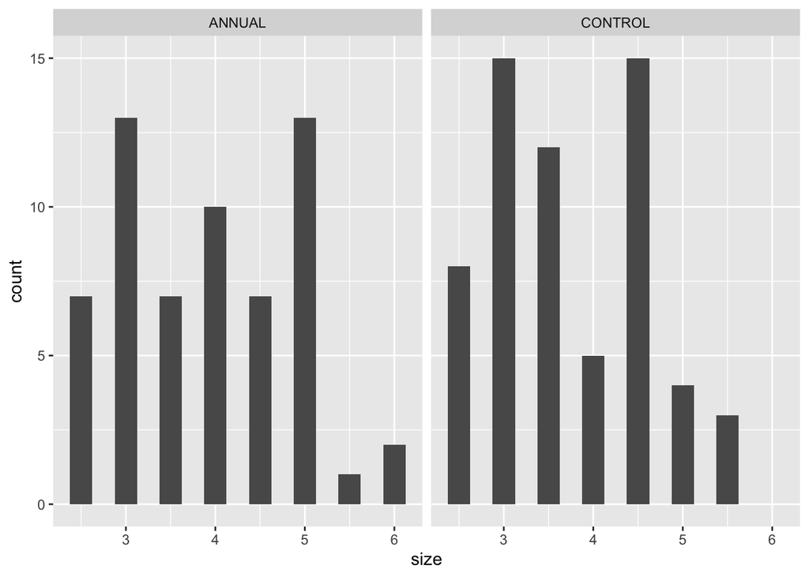

```r
ggplot(data = purp_urch_jan_2010, aes(x = size)) +
  geom_histogram(bins = 15) +
  facet_wrap(~treatment)
```

```r
#plot the data with size on the x-axis, create histograms with 15 bins for clarity, and use facet_wrap to separate by treatment
```

Takeaways: The two plots are fairly similar in spread, although none of the control group reached a diameter of 6 cm. The annual group appears slightly more uniform in distribution across sizes, while the control group appears to have a stronger central tendency. However, it’s possible that both groups are still normally distributed.

Create a Q-Q plot comparing the two treatment types.

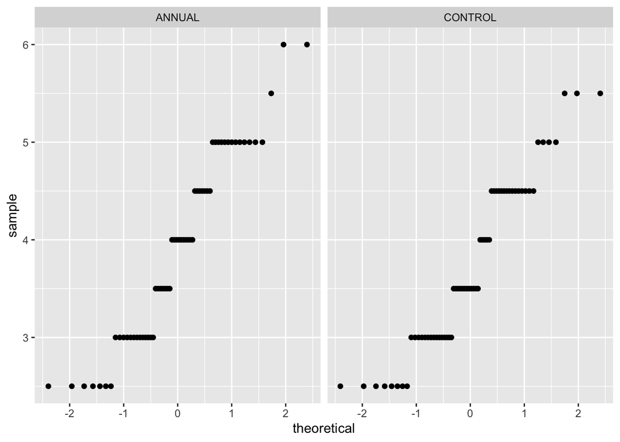

```r
ggplot(data = purp_urch_jan_2010, aes(sample = size)) +
  geom_qq() +
  facet_wrap(~treatment)
```

```r
#plot the data according to size, create a Q-Q plot, and separate according to treatment.
```

### 3. Data table

Create a data table that displays descriptive statistics for each group. Include at least mean, standard deviation, and sample size.

```r
urchin_table <- purp_urch_jan_2010 %>%
  group_by(treatment) %>%
  summarise("Mean Diameter (cm)" = mean(size),
            "Median Diameter (cm)" = median(size),
            "Standard Deviation (cm)" = sd(size),
            "Sample Size" = n())

kbl(urchin_table) %>%
  kable_styling()
```

| treatment | Mean Diameter (cm) | Median Diameter (cm) | Standard Deviation (cm) | Sample Size |
| --- | --- | --- | --- | --- |
| ANNUAL | 3.916667 | 4.0 | 0.9662380 | 60 |
| CONTROL | 3.725807 | 3.5 | 0.8668646 | 62 |

```r
#create a new subset that will show statistics; group the data by treatment to separate the two groups; calculate the mean, median, standard deviation, and sample size for both species; and format the table for clarity and visual appeal
```

### 4. Perform a two-sample t-test to compare means between the two groups

```r
annual_sample <- purp_urch_jan_2010 %>%
  filter(treatment == "ANNUAL") %>%
  pull(size)
#create a vector from the data that filters only urchins from the "ANNUAL" group, and pull the size of each of those urchins

control_sample <- purp_urch_jan_2010 %>%
  filter(treatment == "CONTROL") %>%
  pull(size)
#create a vector from the data that filters only urchins from the "CONTROL" group, and pull the size of each of those urchins

t.test(x = annual_sample, y = control_sample)
```

```
##
##  Welch Two Sample t-test
##
## data:  annual_sample and control_sample
## t = 1.1472, df = 117.66, p-value = 0.2536
## alternative hypothesis: true difference in means is not equal to 0
## 95 percent confidence interval:
##  -0.1386165  0.5203369
## sample estimates:
## mean of x mean of y
##  3.916667  3.725806
```

```r
#conduct a two-sample t-test of the vectors
```

### 5. Discussion of Results

The means of both groups are relatively close (3.916667 cm for the annual treatment group and 3.725806 cm for the control group), with the annual treatment group having a higher mean diameter by 0.190861 cm. Considering that the urchins were measured to the nearest half centimeter, drawing conclusions about how treatment affects size seems potentially irresponsible. This is further supported by the standard deviations for each group (0.9662380 for the annual treatment and 0.8668646 for the control group), which show that the mean of each group is within one standard deviation of the other mean. Additionally, our p-value is well above zero, which means that we cannot reasonably reject our null hypothesis that the two samples were taken from populations with the same mean. This is discussed further ins section 6. To summarize, while there was a difference in the mean diameter of both groups, we cannot responsibly conclude that it is because of the difference in treatment.

### 6. Meaning of the p-value

Our p-value tells us that if these samples were selected from populations with the same mean, there is a 0.2536 probability (25.36% chance) that these samples would have ended up having the difference in means that we found. That is well above zero, which means that it is entirely possible that these samples were selected from populations with the same mean, and we cannot reject our null hypothesis.